# Benchmarking Scripts

Cordell Browne

# Introduction

In theory benchmarking studies should rigorously compare the performance of different methods using well-characterized benchmark data sets, determining the performance of each method [1]. This study simply measures the differences in memory usage and time that it takes to prepare a fastq index between select bioinformatics software.

# Background

*Samtools*| Samtools’ fqidx functions can indexe reference sequence or extract subsequence in the FASTQ format from indexed reference sequence. . When regions are specified, the subsequences will be retrieved and printed to stdout in the FASTQ format. Developers warn that samtools fqidx should only be used on fastq files with a small number of entries. Attempting to use aa file containing millions of short sequencing reads will produce an index that is almost as big as the original file, and searches using the index will be slow and memory consuming [2]

*Pyfastx*| Pyfastx’s object types for Fasta and Fastq are the main components responsible for building index and random access to sequences from plain or gzipped FASTA/Q files. These two objects behave like Python list and dict, allowing users to obtain a Sequence and Read object by index or name. The Sequence object behaves like a Python string that can be sliced to obtain subsequences and holds substantial useful information such as name, description, GC content, nucleotide sequence and reverse complement sequence.Pyfastx’s Sequence and Read objects allow users to extract the raw string of a sequence as it appears in the FASTA/Q file. [3]

*Bioperl*| “Inherits functions for managing dbm files from Bio::Index::Abstract.pm, and provides the basic funtionality for indexing fastq files, and retrieving the sequence from them. Note: for best results ‘use strict’. Bio::Index::Fastq supports the Bio::DB::BioSeqI interface, meaning it can be used as a Sequence database for other parts of bioperl” [5]

# Results

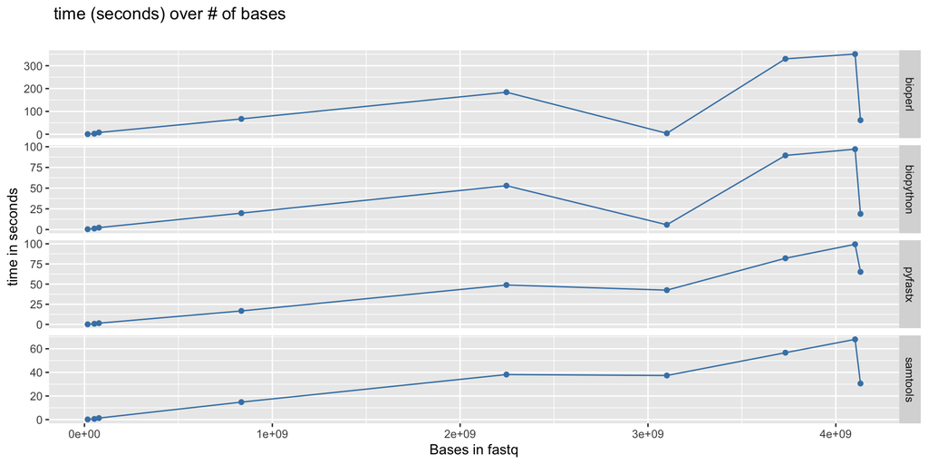

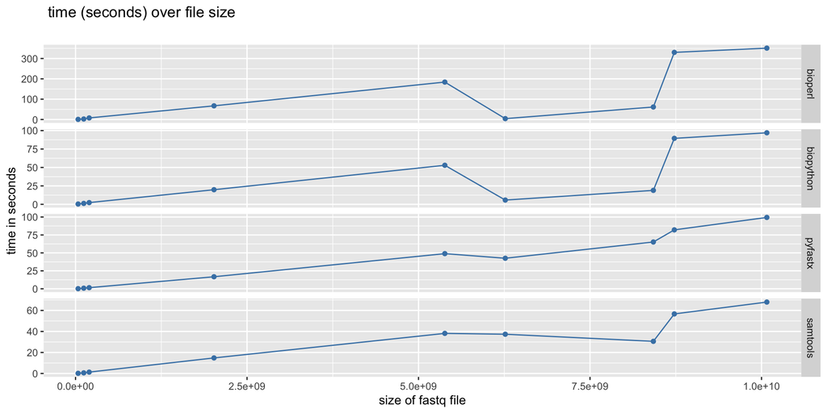

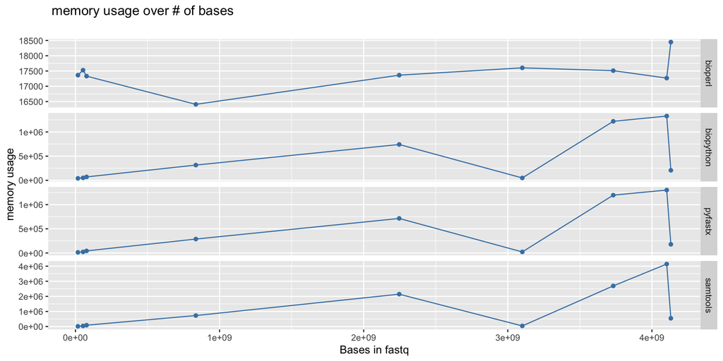

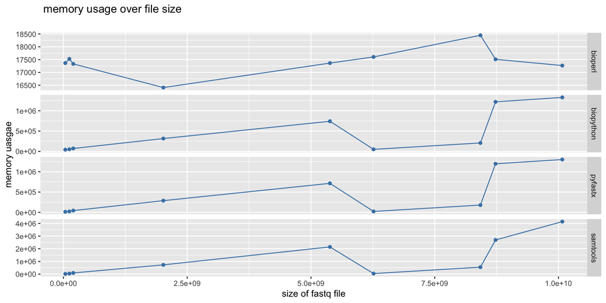

[output not shown]

# About the Data

Data was acquired from genome sequence archive browser

## Data

[output not shown]

# References

1. Weber, L.M., Saelens, W., Cannoodt, R. et al. Essential guidelines for computational method benchmarking. Genome Biol 20, 125 (2019). https://doi.org/10.1186/s13059-019-1738-8
2. Danecek P, Bonfield JK, Liddle J, Marshall J, Ohan V, Pollard MO, Whitwham A, Keane T, McCarthy SA, Davies RM, Li H, Twelve years of SAMtools and BCFtools, GigaScience (2021) 10(2) giab008 [33590861]
3. Lianming Du, Qin Liu, Zhenxin Fan, Jie Tang, Xiuyue Zhang, Megan Price, Bisong Yue, Kelei Zhao, Pyfastx: a robust Python package for fast random access to sequences from plain and gzipped FASTA/Q files, Briefings in Bioinformatics, Volume 22, Issue 4, July 2021, bbaa368, https://doi.org/10.1093/bib/bbaa368
4. Peter J. A. Cock, Tiago Antao, Jeffrey T. Chang, Brad A. Chapman, Cymon J. Cox, Andrew Dalke, Iddo Friedberg, Thomas Hamelryck, Frank Kauff, Bartek Wilczynski, Michiel J. L. de Hoon, Biopython: freely available Python tools for computational molecular biology and bioinformatics, Bioinformatics, Volume 25, Issue 11, 1 June 2009, Pages 1422–1423, https://doi.org/10.1093/bioinformatics/btp163
5. https://metacpan.org/pod/Bio::Index::Fastq
6. Genome Sequence Archieve; https://ngdc.cncb.ac.cn/gsa/browse/